# Series

## 面积图

- Series.plot.area() 和 DataFrame.plot.area()
- 是面积图的基础操作，默认情况下 x 轴为索引，y 轴为值或者所有数字列。

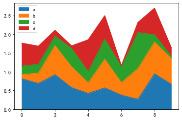

```python
df = pd.DataFrame(np.random.rand(10, 4), columns=['a', 'b', 'c', 'd'])

df.plot.area()
```

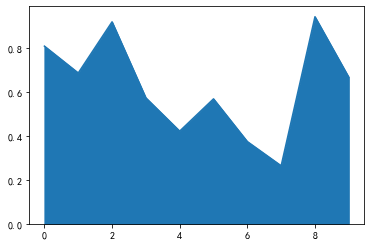

```python
df.a.plot.area() # 单个列
```

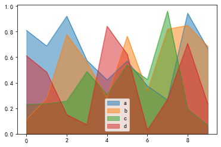

```python
# 堆积

# 要生成未堆积的图，请传入 stack = False，除非另有说明，否则Alpha值将设置为0.5。

df.plot.area(stacked=False)
```

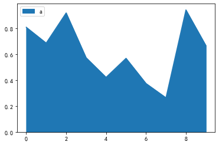

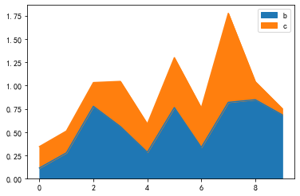

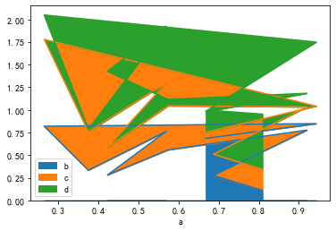

```python
# 指定轴

# 可以指定 x 和 y 轴：

df.plot.area(y='a')
df.plot.area(y=['b', 'c'])
df.plot.area(x='a')
```

## 散点图

- 散点图（Scatter graph）也叫 X-Y 图，它将所有的数据以点的形式展现在直角坐标系上，
- 以显示变量之间的相互影响程度，点的位置由变量的数值决定。

图形意义

散点图经常与回归线（就是最准确地贯穿所有点的线）结合使用，归纳分析现有数据以进行预测分析。

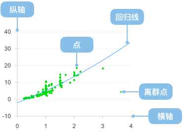

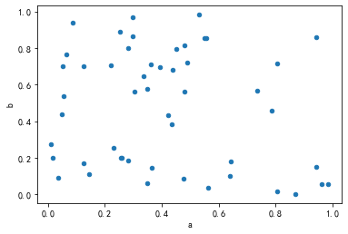

```python
# 创建方法

# 可以使用 DataFrame.plot.scatter() 方法绘制散点图。 散点图要求 x 和 y 轴为数字列。这些可以通过 x 和 y 关键字指定。

df = pd.DataFrame(np.random.rand(50, 4),
                  columns=['a', 'b', 'c', 'd'])

df.plot.scatter(x='a', y='b')
```

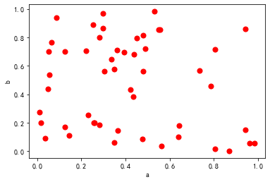

```python
df.plot.scatter(x='a', y='b', c='r', s=50)
```

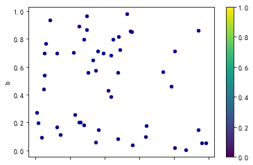

```python
# 色阶栏

# colorbar=True 在当前坐标区或图的右侧显示一个垂直颜色栏。颜色栏显示当前颜色图并指示数据值到颜色图的映射。

df.plot.scatter(x='a', y='b', c='DarkBlue', colorbar=True)
```

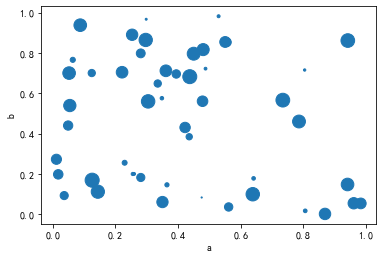

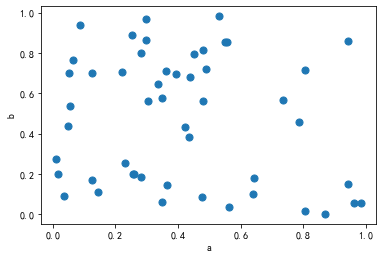

```python
# 点大小

# s 可以指定点的大小：

df.plot.scatter(x='a', y='b', s=df['c'] * 200)
df.plot.scatter(x='a', y='b', s=50) # 同样大小
```

# matplotlib.pyplot可视化

```
plot.line() # 折线的全写方式
plot.bar() # 柱状图
plot.barh() # 横向柱状图 （条形图）
plot.hist() # 直方图
plot.box() # 箱形图
plot.kde() # 核密度估计图
plot.density() # 同 df.plot.kde()
plot.area() # 面积图
plot.pie() # 饼图
plot.scatter() # 散点图
plot.hexbin() # 六边形箱体图，或简称六边形图
```

```python
# 1. 风格

#  可对全局的样式进行配置：
#  plt.style.use('seaborn-whitegrid')
#  查看可用样式
#  plt.style.available
```

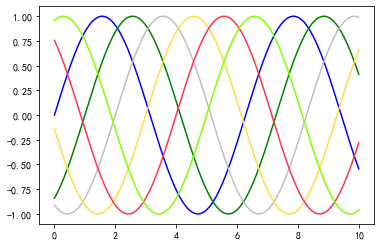

```python
# 2. 线条颜色

# 以下几种赋值方式：

plt.plot(x, np.sin(x - 0), color='blue')        # 颜色名称指定
plt.plot(x, np.sin(x - 1), color='g')           # 颜色简写名称指定(rgbcmyk)
plt.plot(x, np.sin(x - 2), color='0.75')        # 介于0-1之间的灰阶值
plt.plot(x, np.sin(x - 3), color='#FFDD44')     # 16进制的RRGGBB值
plt.plot(x, np.sin(x - 4), color=(1.0,0.2,0.3)) # RGB元组的颜色值，介于0-1
plt.plot(x, np.sin(x - 5), color='chartreuse'); # 能支持所有HTML颜色名称值
```

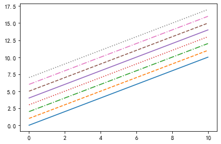

```python
# 3. 线条的风格

# 对应下方
plt.plot(x, x + 0, linestyle='solid')
plt.plot(x, x + 1, linestyle='dashed')
plt.plot(x, x + 2, linestyle='dashdot')
plt.plot(x, x + 3, linestyle='dotted');

# 还可以用形象的符号代表线条风格
plt.plot(x, x + 4, linestyle='-')  # 实线
plt.plot(x, x + 5, linestyle='--') # 虚线
plt.plot(x, x + 6, linestyle='-.') # 长短点虚线
plt.plot(x, x + 7, linestyle=':');  # 点线
```

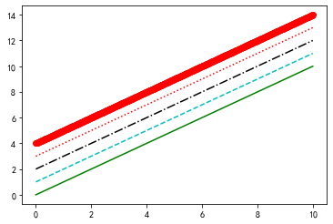

```python
# 4. 颜色线条合并

# character        color
# =============    ======
# ``'b'``          blue
# ``'g'``          green
# ``'r'``          red
# ``'c'``          cyan
# ``'m'``          magenta
# ``'y'``          yellow
# ``'k'``          black
# ``'w'``          white

# linestyle 和 color 参数能够合并成一个非关键字参数：

plt.plot(x, x + 0, '-g')  # 绿色实线
plt.plot(x, x + 1, '--c') # 天青色虚线
plt.plot(x, x + 2, '-.k') # 黑色长短点虚线
plt.plot(x, x + 3, ':r');  # 红色点线
plt.plot(x, x + 4, 'or') # 红色大圆点
# 其他 ['o', '.', ',', 'x', '+', 'v', '^', '<', '>', 's', 'd']
```

```
(-0.5, 10.5, -1.0999996694475616, 9.900000330552439)
```

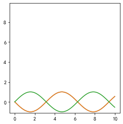

```python
# 5.  坐标轴范围

# 如果对自动匹配的坐标轴范围不满意，可以自己进行相关调整。

plt.plot(x, -np.sin(x))
plt.xlim(-1, 5)
plt.ylim(-2.5, 2.5);

# axis 也可以，传入 [xmin, xmax, ymin, ymax]
plt.plot(x, -np.sin(x))
plt.axis([-1, 5, -2.5, 2.5]);
# 设置x轴与y轴组成正方形，可参考文档关于字符串说明
plt.plot(x, np.sin(x))
plt.axis('square')
```

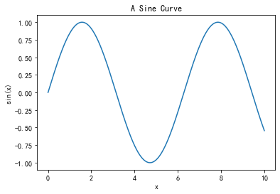

```python
# 6. 坐标轴标签

# 可设置轴上的标签文本：

plt.plot(x, np.sin(x))
plt.title("A Sine Curve") # 标题
plt.xlabel("x") # x 轴标签
plt.ylabel("sin(x)") # y 轴标签
```

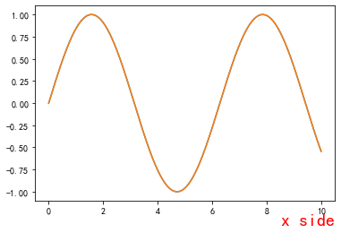

```python
# 标签的位置、大小和风格可以通过上面函数的可选参数进行设置：

plt.plot(x, np.sin(x))
plt.plot(x, np.cos(x))
plt.xlabel("x side",
           color='r', # 颜色
           fontsize=20, # 字号
           labelpad=-1, # 与轴的上下距离
           loc='right' # 位置居右
          )
```

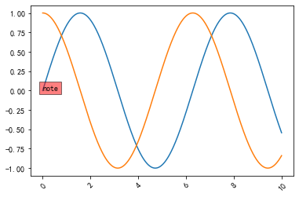

```python
# 7. 其他

plt.figure(figsize=(6,4)) # 图形和大小
plt.plot(x, np.sin(x))
plt.plot(x, np.cos(x))
plt.xticks(rotation=45) # x 轴上标签的角度


# 指定坐标上标注一个红框的 note 字符, 在指定其位置添加一个文本框,用来说明一些数据特征
plt.text(0,0, 'note', bbox=dict(facecolor='red', alpha=0.5))
```

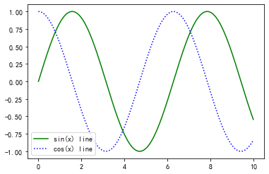

```python
# 8. 图例

plt.plot(x, np.sin(x), '-g', label='sin(x)')
plt.plot(x, np.cos(x), ':b', label='cos(x)')
plt.legend() # 图例

# 其他参数
plt.legend(['sin(x) line', 'cos(x) line']) # 指定图例内容
```

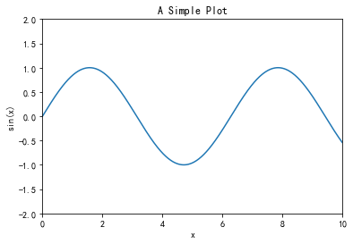

```python
# 9. 面向对象操作

ax = plt.axes()
ax.plot(x, np.sin(x))
ax.set(xlim=(0, 10), ylim=(-2, 2),
       xlabel='x', ylabel='sin(x)',
       title='A Simple Plot')
```

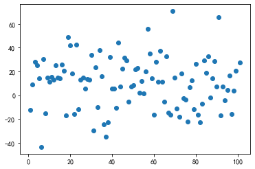

```python
# 10. 散点图

# 简单使用：

fig = plt.figure()
x = np.linspace(1, 101, 100, dtype='int')
y = np.random.normal(10, 20, size=100)
plt.scatter(x, y)
```

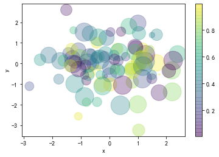

```python
# 更多参数：

rng = np.random.RandomState(123)
x = rng.randn(100)
y = rng.randn(100)
colors = rng.rand(100)
sizes = 1000 * rng.rand(100)

plt.scatter(x, y,
            c=colors, # 标记颜色
            s=sizes, # 点标记大小
            alpha=0.3, # 透明度
            cmap='viridis' # 色系
           )
plt.xlabel('x')
plt.ylabel('y')
plt.colorbar();  # 显示颜色对比条
```

## 认识matplotlib.plot

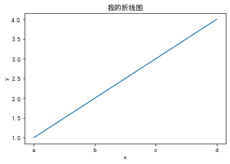

```python
# 使用示例

# 以下是一个简单的折线图示例：

# 约定简写为 plt
# import matplotlib.pyplot as plt

x = ['a', 'b', 'c', 'd']
y = [1, 2, 3, 4]

plt.plot(x, y) # 配置 x 轴和 y 轴数据序列
plt.xlabel('x') # 轴标签名
plt.ylabel('y')
plt.title('我的折线图') # 图形标题
```

结构

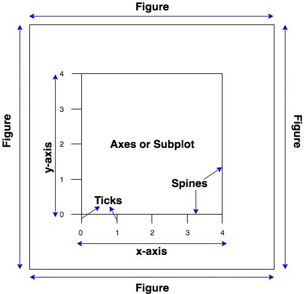

```
在 Matplotlib 中，figure 是 axes 的父容器，而 axes 是 figure 的内部元素，而我们常用的各种图表、图例、坐标轴等则又是 axes 的内部元素。

    图形（类 plt.Figure 的一个实例）可以被认为是一个包括所有维度、图像、文本和标签对象的容器，相当于是提供了画板。
    维度（类 plt.Axes 的一个实例）则定义了画板中的每一个绘图对象 Axes，一个有边界的格子包括刻度和标签，相当于画板内的各个子图。
    plt.subplot，主要接收3个数字或1个3位数（自动解析成3个数字，要求解析后数值合理）作为子图的行数、列数和当前子图索引，索引从1开始（与MATLAB保存一致），返回一个axes对象用于绘图操作。这里，可以理解成是先隐式执行了plt.figure，然后在创建的figure对象上添加子图，并返回当前子图实例
    plt.subplots，主要接收一个行数nrows和列数ncols作为参数（不含第三个数字），创建一个figure对象和相应数量的axes对象，同时返回该figure对象和axes对象嵌套列表，并默认选择最后一个子图作为"当前"图

一般，我们会使用变量名 fig 来指代图形对象，以及变量名 ax 来指代维度变量，创建了维度，可以使用 ax.plot 方法将数据绘制在图表上。

创建这这元素的方法：

import numpy as np
import matplotlib.pyplot as plt

fig = plt.figure()
ax = plt.axes()

x = np.linspace(0, 10, 500)
# ax.plot(x, np.sin(x)) 同下，也可创建图形
plt.plot(x, np.sin(x))

# 创建两条线
plt.plot(x, np.sin(x))
plt.plot(x, np.cos(x))
# plt.show() 可省略
```

## 绘图的2个接口

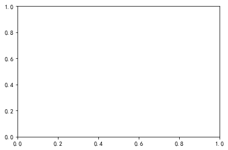

```python
# 1.对于所有的 Matplotlib 图表来说，我们都需要从创建图形和维度开始。图形和维度可以使用下面代码进行最简形式的创建：

fig = plt.figure()# 画板 , 可以被认为是一个包括所有维度、图像、文本和标签对象的容器
ax = plt.axes() # 坐标系,  一个有边界的格子包括刻度和标签，最终还有我们画在上面的图表元素

# 使用变量名fig来指代图形(画板)对象，以及变量名ax来指代维度变量(坐标系)。
```

```python
#一旦我们创建了维度，我们可以使用ax.plot方法将数据绘制在图表上。下面是一个简单的正弦函数图形：

fig = plt.figure()
ax = plt.axes()

x = np.linspace(0, 10, 1000)
ax.plot(x, np.sin(x));
```

[output not shown]

```python
# 2.同样的，我们可以使用 pylab 接口（MATLAB 风格的接口）帮我们在后台自动创建这两个对象：
plt.plot(x, np.sin(x));
```

[output not shown]

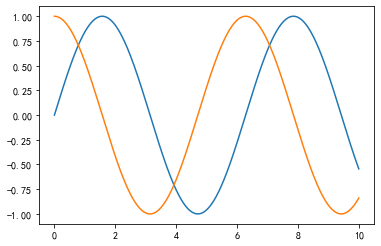

```python
#如果我们需要在同一幅图形中绘制多根线条，只需要多次调用plot函数即可：

plt.plot(x, np.sin(x))
plt.plot(x, np.cos(x));
```

**这就是在 Matplotlib 中绘制简单函数图像的所有接口了**

## 控制坐标轴和线条外观的细节。

### 调整折线图：线条颜色和风格

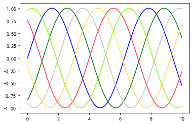

```python
#调整折线图：线条颜色和风格
plt.plot(x, np.sin(x - 0), color='blue')        # 通过颜色名称指定
plt.plot(x, np.sin(x - 1), color='g')           # 通过颜色简写名称指定(rgbcmyk)
plt.plot(x, np.sin(x - 2), color='0.75')        # 介于0-1之间的灰阶值
plt.plot(x, np.sin(x - 3), color='#FFDD44')     # 16进制的RRGGBB值
plt.plot(x, np.sin(x - 4), color=(1.0,0.2,0.3)) # RGB元组的颜色值，每个值介于0-1
plt.plot(x, np.sin(x - 5), color='chartreuse')
```

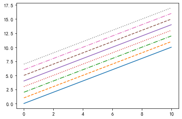

```python
# 类似的，通过linestyle关键字参数可以指定线条的风格：
plt.plot(x, x + 0, linestyle='solid')
plt.plot(x, x + 1, linestyle='dashed')
plt.plot(x, x + 2, linestyle='dashdot')
plt.plot(x, x + 3, linestyle='dotted');

# 还可以用形象的符号代表线条风格
plt.plot(x, x + 4, linestyle='-')  # 实线
plt.plot(x, x + 5, linestyle='--') # 虚线
plt.plot(x, x + 6, linestyle='-.') # 长短点虚线
plt.plot(x, x + 7, linestyle=':');  # 点线
```

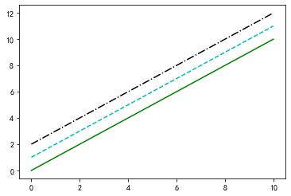

```python
#如果你喜欢更简洁的代码，这些linestyle和color参数能够合并成一个非关键字参数，传递给plt.plot()函数：

plt.plot(x, x + 0, '-g')  # 绿色实线
plt.plot(x, x + 1, '--c') # 天青色虚线
plt.plot(x, x + 2, '-.k') # 黑色长短点虚线
```

### 调整折线图：坐标轴范围

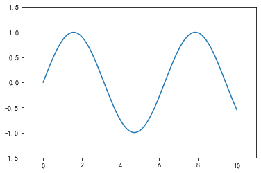

```python
#Matplotlib 会自动选择非常合适的坐标轴范围来绘制你的图像，
#但是有些情况下你也需要自己进行相关调整。
#使用plt.xlim()和plt.ylim()函数可以调整坐标轴的范围：
plt.plot(x, np.sin(x))

plt.xlim(-1, 11)
plt.ylim(-1.5, 1.5);
```

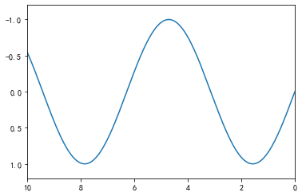

```python
#如果某些情况下你希望将坐标轴反向，你可以通过上面的函数实现，将参数顺序颠倒即可：

plt.plot(x, np.sin(x))

plt.xlim(10, 0)
plt.ylim(1.2, -1.2);
```

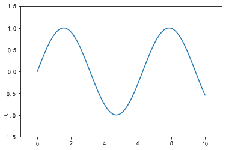

```python
#相关的函数还有plt.axis()（注意：这不是plt.axes()函数，函数名称是 i 而不是 e）。
#这个函数可以在一个函数调用中就完成 x 轴和 y 轴范围的设置，传递一个  [xmin, xmax, ymin, ymax]  的列表参数即可：

plt.plot(x, np.sin(x))
plt.axis([-1, 11, -1.5, 1.5]);
```

```python
# 当然plt.axis()函数不仅能设置范围，还能像下面代码一样将坐标轴压缩到刚好足够绘制折线图像的大小：

plt.plot(x, np.sin(x))
plt.axis('tight')
```

[output not shown]

```
(-0.5, 10.5, -1.0999971452300779, 1.099999549246729)
```

```
(-0.5, 10.5, -1.0999971452300779, 1.099999549246729)
```

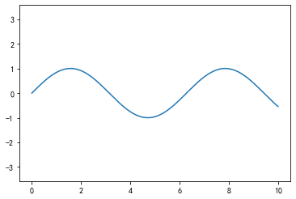

```python
# 还可以通过设置'equal'参数设置x轴与y轴使用相同的长度单位：

plt.plot(x, np.sin(x))
plt.axis('equal')
```

### 折线图标签

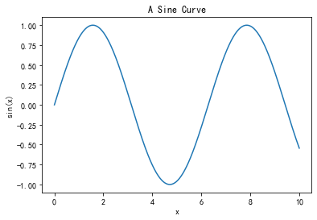

```python
plt.plot(x, np.sin(x))
plt.title("A Sine Curve")
plt.xlabel("x")
plt.ylabel("sin(x)");
```

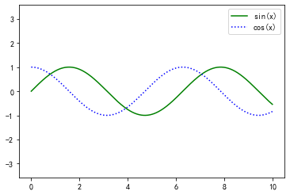

```python
#Matplotlib 也内建了函数来快速创建图例。估计你也猜到了，通过plt.legend()函数可以实现这个需求。
#虽然有很多种正确的方法来指定图例，作者认为最简单的方法是通过在绘制每条线条时指定对应的label关键字参数来使用这个函数：

plt.plot(x, np.sin(x), '-g', label='sin(x)')
plt.plot(x, np.cos(x), ':b', label='cos(x)')
plt.axis('equal')

plt.legend()
```

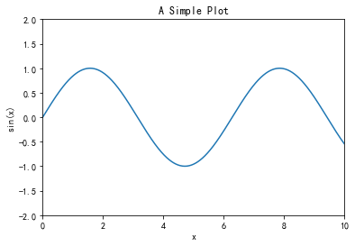

```python
# Matplotlib 的坑

# 虽然大多数的plt函数都可以直接转换为ax的方法进行调用（例如plt.plot() → ax.plot()，plt.legend() → ax.legend()等），但是并不是所有的命令都能应用这种情况。特别是用于设置极值、标签和标题的函数都有一定的改变。下表列出了将 MATLAB 风格的函数转换为面向对象的方法的区别：

#     plt.xlabel() → ax.set_xlabel()
#     plt.ylabel() → ax.set_ylabel()
#     plt.xlim() → ax.set_xlim()
#     plt.ylim() → ax.set_ylim()
#     plt.title() → ax.set_title()

# 在面向对象接口中，与其逐个调用上面的方法来设置属性，更常见的使用ax.set()方法来一次性设置所有的属性：

ax = plt.axes()
ax.plot(x, np.sin(x))
ax.set(xlim=(0, 10), ylim=(-2, 2),
       xlabel='x', ylabel='sin(x)',
       title='A Simple Plot');
```

### 子图

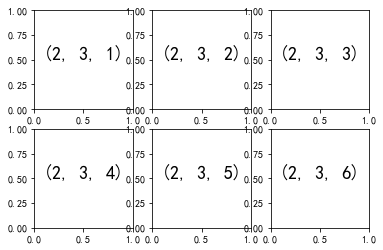

```python
for i in range(1, 7):
    plt.subplot(2, 3, i)
    plt.text(0.5, 0.5, str((2, 3, i)),
             fontsize=18, ha='center')
```

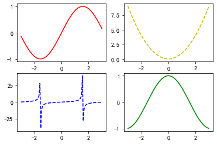

```python
x=np.linspace(-3,3,100)
plt.subplot(2, 2,1)
plt.plot(x,np.sin(x),"-r")

plt.subplot(2, 2,2)
plt.plot(x,x**2,"--y")

plt.subplot(2, 2,3)
plt.plot(x,np.tan(x),"--b")

plt.subplot(2,2,4)
plt.plot(x,np.cos(x),"-g")
```

## 举例说明

**绘图他就是点对点的素描图**

### 柱状图和条形图

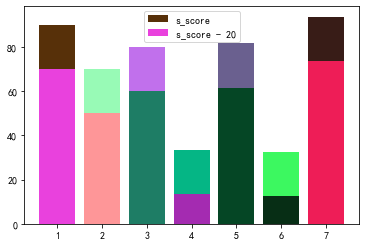

```python
# 1. 柱状图
s=round(score.groupby("s_id")["s_score"].mean(),2)
plt.bar(s.index,s.values,color=np.random.rand(21).reshape(7,3))
plt.bar(s.index,s.values -20,color=np.random.rand(21).reshape(7,3))
plt.legend(["s_score","s_score - 20"])
```

```python
df1.head()
```

|  | city | companyFullName | companyId | companyLabelList | companyShortName | companySize | businessZones | firstType | secondType | education | industryField | positionId | positionAdvantage | positionName | positionLables | salary | workYear |
| --- | --- | --- | --- | --- | --- | --- | --- | --- | --- | --- | --- | --- | --- | --- | --- | --- | --- |
| 0 | 上海 | 纽海信息技术(上海)有限公司 | 8581 | ['技能培训', '节日礼物', '带薪年假', '岗位晋升'] | 1号店 | 2000人以上 | ['张江'] | 技术 | 数据开发 | 硕士 | 移动互联网 | 2537336 | 知名平台 | 数据分析师 | ['分析师', '数据分析', '数据挖掘', '数据'] | 7k-9k | 应届毕业生 |
| 1 | 上海 | 上海点荣金融信息服务有限责任公司 | 23177 | ['节日礼物', '带薪年假', '岗位晋升', '扁平管理'] | 点融网 | 500-2000人 | ['五里桥', '打浦桥', '制造局路'] | 技术 | 数据开发 | 本科 | 金融 | 2427485 | 挑战机会,团队好,与大牛合作,工作环境好 | 数据分析师-CR2017-SH2909 | ['分析师', '数据分析', '数据挖掘', '数据'] | 10k-15k | 应届毕业生 |
| 2 | 上海 | 上海晶樵网络信息技术有限公司 | 57561 | ['技能培训', '绩效奖金', '岗位晋升', '管理规范'] | SPD | 50-150人 | ['打浦桥'] | 设计 | 数据分析 | 本科 | 移动互联网 | 2511252 | 时间自由,领导nic | 数据分析师 | ['分析师', '数据分析', '数据'] | 4k-6k | 应届毕业生 |
| 3 | 上海 | 杭州数云信息技术有限公司上海分公司 | 7502 | ['绩效奖金', '股票期权', '五险一金', '通讯津贴'] | 数云 | 150-500人 | ['龙华', '上海体育场', '万体馆'] | 市场与销售 | 数据分析 | 本科 | 企业服务,数据服务 | 2427530 | 五险一金 绩效奖金 带薪年假 节日福利 | 大数据业务分析师【数云校招】 | ['商业', '分析师', '大数据', '数据'] | 6k-8k | 应届毕业生 |
| 4 | 上海 | 上海银基富力信息技术有限公司 | 130876 | ['年底双薪', '通讯津贴', '定期体检', '绩效奖金'] | 银基富力 | 15-50人 | ['上海影城', '新华路', '虹桥'] | 技术 | 软件开发 | 本科 | 其他 | 2245819 | 在大牛下指导 | BI开发/数据分析师 | ['分析师', '数据分析', '数据', 'BI'] | 2k-3k | 应届毕业生 |

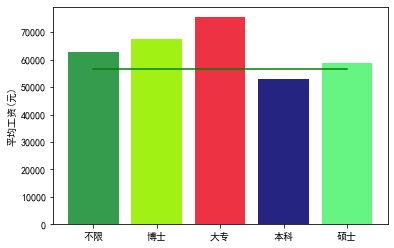

```python
# 1.查询不同学历的平均工资情况

s=df1.groupby("education")["companyId"].mean()
plt.bar(s.index,s.values,color=np.random.rand(15).reshape(5,3))
plt.plot(s.index,[df1["companyId"].mean()]*5,c="g")#平均工资的参考线
plt.ylabel("平均工资(元)")
# plt.grid()#显示网格线
```

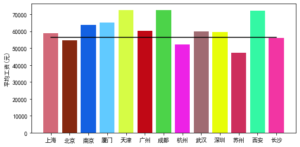

```python
# 1.查询不同城市的平均工资情况
plt.figure(figsize=(8,4))
s=df1.groupby("city")["companyId"].mean()
plt.bar(s.index,s.values,color=np.random.rand(39).reshape(13,3))
plt.plot(s.index,[df1["companyId"].mean()]*13,c="k")#平均工资的参考线
plt.ylabel("平均工资(元)")
# plt.grid()#显示网格线
```

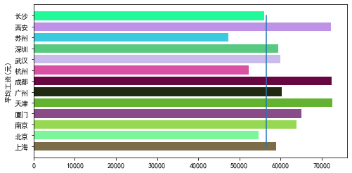

```python
# 1.查询不同岗位的平均工资情况
plt.figure(figsize=(8,4))

s=df1.groupby("city")["companyId"].mean()
plt.barh(s.index,s.values,color=np.random.rand(39).reshape(13,3))

plt.ylabel("平均工资(元)")
# plt.grid()#显示网格线

plt.plot([df1["companyId"].mean()]*13,s.index)#平均工资的参考线
```

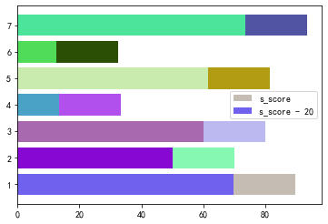

```python
# 2.条形图
s=round(score.groupby("s_id")["s_score"].mean(),2)
plt.barh(s.index,s.values,color=np.random.rand(21).reshape(7,3))
plt.barh(s.index,s.values -20,color=np.random.rand(21).reshape(7,3))
plt.legend(["s_score","s_score - 20"])
```